# ontology_DAG: a class for ontology data

Zuguang Gu ( z.gu@dkfz.de )

2023-10-16

Ontologies are represented in a form of directed acyclic diagram (DAG). A DAG is a generalized form of tree where a parent term can have multiple child terms, and also a child term can have multiple parent terms. The DAG is directed and a link connects from a child term to a parent term, representing “the child is a sub-class of the parent.” (left panel). In some other cases, the direction can also be reversed to represent “a parent includes the child” (right panel).

[figure not shown]

In this vignette, I will introduce the `ontology_DAG` class as well as related functions with a tiny example. As shown in the following diagram, there are six terms in the DAG where term “a” is the root, term “e” and “f” are two leaf terms. Note term “c” has two parents.

[figure not shown]

## Construct the object

The DAG object is constructed via a list of parent-child pairs. The following code constructs a DAG in the diagram above.

```r
library(simona)
parents  = c("a", "a", "b", "b", "c", "d")
children = c("b", "c", "c", "d", "e", "f")
dag = create_ontology_DAG(parents, children)
```

Typing `dag` prints the basic information of the DAG.

```r
dag
```

```
## An ontology_DAG object:
##   Source: Ontology
##   6 terms / 6 relations
##   Root: a
##   Terms: a, b, c, d, ...
##   Max depth: 3
##   Avg number of parents: 1.20
##   Aspect ratio: 0.67:1 (based on the longest distance to root)
##                 0.68:1 (based on the shortest distance to root)
```

Aspect ratio is calculated as `width/height`, where `width` is the largest number of terms on a specific height (i.e. `max(table(height(dag)))`). Definition of the height of a term in the DAG depends on whether using the longest or the shortest distance from root. The aspect ratio gives an impression of how the shape of the DAG looks like (fat or slim).

The `ontology_DAG` object can also be constructed by a vector of parent-child links:

```r
dag = create_ontology_DAG(c("a-b", "a-c", "b-c", "b-d", "c-e", "d-f"))
```

Following functions return the root term, leaf terms and test whether terms are leaves.

```r
dag_root(dag)
```

```
## [1] "a"
```

```r
dag_leaves(dag)
```

```
## [1] "e" "f"
```

```r
dag_is_leaf(dag, letters[1:6])
```

```
##     a     b     c     d     e     f
## FALSE FALSE FALSE FALSE  TRUE  TRUE
```

`dag_all_terms()` returns a vector of all terms. `dag_n_terms()` simply returns the number of all terms in the DAG.

```r
dag_all_terms(dag)
```

```
## [1] "a" "b" "c" "d" "e" "f"
```

```r
dag_n_terms(dag)
```

```
## [1] 6
```

## DAG traverse

Numbers of child/parent/offspring/ancestor terms.

```r
n_children(dag)
```

```
## a b c d e f
## 2 2 1 1 0 0
```

```r
n_parents(dag)
```

```
## a b c d e f
## 0 1 2 1 1 1
```

```r
n_offspring(dag)
```

```
## a b c d e f
## 5 4 1 1 0 0
```

```r
n_ancestors(dag)
```

```
## a b c d e f
## 0 1 2 2 3 3
```

`n_connected_leaves()` returns numbers of leaves that every term can reach (or has a finite directed distance to). Leaf terms have value of zero.

```r
n_connected_leaves(dag)
```

```
## a b c d e f
## 2 2 1 1 0 0
```

Parents/children of a single term or union of parents/children of a group of terms. The term argument can be a single term name or a vector of term names.

```r
dag_parents(dag, "c")
```

```
## [1] "a" "b"
```

```r
dag_parents(dag, c("d", "e")) # union of d's parents and e's parents
```

```
## [1] "b" "c"
```

```r
dag_children(dag, "b")
```

```
## [1] "c" "d"
```

It is similar to get offspring/ancestor terms of a single term or a group of terms.

```r
dag_offspring(dag, "b")
```

```
## [1] "c" "d" "e" "f"
```

```r
dag_ancestors(dag, "e")
```

```
## [1] "a" "b" "c"
```

In many methods, when constructing the set of a term’s ancestors of offsprings, the set itself is also included. In `dag_offspring()` and `dag_ancestors()`, an argument `include_self` can be set to `TRUE` to include the term itself.

```r
dag_offspring(dag, "b", include_self = TRUE)
```

```
## [1] "b" "c" "d" "e" "f"
```

```r
dag_ancestors(dag, "e", include_self = TRUE)
```

```
## [1] "a" "b" "c" "e"
```

## Distance

The depth of a term is defined as the longest distance from root and is calculated by `dag_depth()`. If you want the shortest distance from root, use `dag_shortest_dist_from_root()`.

```r
dag_depth(dag)
```

```
## a b c d e f
## 0 1 2 2 3 3
```

```r
dag_shortest_dist_from_root(dag)
```

```
## a b c d e f
## 0 1 1 2 2 3
```

Similarly, the “height” of a term is defined as the longest distance to its reachable leaf terms. `dag_shortest_dist_to_leaves()` returns the shortest distance to leaves.

```r
dag_height(dag)
```

```
## a b c d e f
## 3 2 1 1 0 0
```

```r
dag_shortest_dist_to_leaves(dag)
```

```
## a b c d e f
## 2 2 1 1 0 0
```

These four functions introduced so far calculate distance from root or to leaves for all terms in the DAG. The following functions are more general which calculates distance from a self-defined group of terms or until a group of terms.

`dag_depth()` is identical to `dag_longest_dist_to_offspring(dag, root)`, and `dag_height()` is identical to `dag_longest_dist_from_ancestors(dag, leaves)` where `root` is a single root term and `leaves` is a vector of all leaf terms in the DAG.

```
dag_longest_dist_to_offspring(dag, from)
dag_shortest_dist_to_offspring(dag, from)
dag_longest_dist_from_ancestors(dag, to)
dag_shortest_dist_from_ancestors(dag, to)
```

Please note, these four functions are applied to all terms. They return a vector with the same length as the total terms in the DAG. If a term is not included in the calculation, e.g. the root term when `from` does not include it, `dag_longest_dist_to_offspring()` and `dag_shortest_dist_to_offspring()` will assign -1 to the root term.

Given any two terms in the DAG, the following four functions calculate their pair-wise distance. There are different ways to calculate the distance:

For two terms $a$ and $b$, `shortest_distances_via_NCA()` calculates the distance as:

$$\min_{t \in \mathrm{CA}(a, b)}(D_{sp}(t, a) + D_{sp}(t, b))$$

where $\mathrm{CA}(a, b)$ is the set of common ancestors (CA) of $a$ and $b$. $D_{sp}(x, y)$ is the shortest distance between $x$ and $y$. In this way, common ancestor $t$ which returns the minimal distance between $a$ and $b$ is called the “nearest common ancestor (NCA)” of $a$ and $b$. The usage of the function is as follows. It returns a symmetric matrix of pair-wise distance of `terms`.

```
shortest_distances_via_NCA(dag, terms)
```

`longest_distances_via_LCA()` calculates the distance as:

$$\mathrm{len}(t, a) + \mathrm{len}(t, b)$$

where $\mathrm{len}(x, y)$ is the longest distance between $x$ and $y$. Common ancestor $t$ is the one with the largest depth in DAG and it is called the lowest common ancestor (LCA) of $a$ and $b$:

$$t = \operatorname*{argmax}_{t \in \mathrm{CA}(a, b)} \delta(t)$$

where $\delta(t)$ is the depth (maximal distance from root) of term $t$. The usage of the function is:

```
longest_distances_via_LCA(dag, terms)
```

The next two functions treat the DAG relations as directional. There is a positive distance value only if a term is an ancestor of the other, or else the distance is set to -1 in the returned distance matrix.

```
shortest_distances_directed(dag, terms)
longest_distances_directed(dag, terms)
```

## Convert to other formats

### To an igraph object

DAG is a graph. `dag_as_igraph()` converts the DAG to an `igraph` object.

```r
g = dag_as_igraph(dag)
g
```

```
## IGRAPH 81a2a63 DN-- 6 6 --
## + attr: name (v/c)
## + edges from 81a2a63 (vertex names):
## [1] a->b a->c b->c b->d c->e d->f
```

Draw the graph with a hierarchical graph layout:

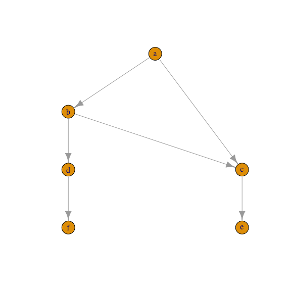

```r
library(igraph)
plot(g, layout = layout.sugiyama)
```

### To a dendrogram object

In a DAG, a term can have multiple parents. A tree is a reduced form of a DAG where a term only has one parent. `dag_treelize()` simplifies a DAG to a tree. The reducing is applied in a breadth-first manner:

Starting from root and on a certain depth, for every term $a$ on this depth, its child term $c$ and parent-child relation are kept only when $\delta_c = \delta_a + 1$. If $c$ is selected, it is marked as visited and will not be checked again. In this way, depths of all terms in the orignal DAG are still identical to the depths in the tree.

```r
tree = dag_treelize(dag)
dag_depth(dag)
```

```
## a b c d e f
## 0 1 2 2 3 3
```

```r
dag_depth(tree)
```

```
## a b c d e f
## 0 1 2 2 3 3
```

Note, although we are talking about “a tree”, `tree` in the example is still an `ontology_DAG` object where only multi-parent relations are removed. If `n_relations + 1 == n_terms`, there is special mark of being a tree in the object.

```r
tree
```

```
## An ontology_DAG object:
##   Source: Ontology, treelized
##   6 terms / 5 relations / a tree
##   Root: a
##   Terms: a, b, c, d, ...
##   Max depth: 3
##   Aspect ratio: 0.67:1
```

When the DAG is a tree, it can be converted to a `dendrogram` object. Since some nodes may only have one child, I add labels on nodes to mark the nodes are there. You can see the link `a->c` is removed from the DAG.

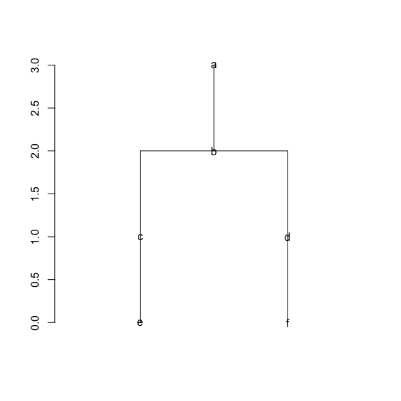

```r
dend = dag_as_dendrogram(tree)
dend = dendrapply(dend, function(d) {
    attr(d, "nodePar") = list(pch = attr(d, "label"))
    d
})
plot(dend, leaflab = "none")
```

Note reducing DAG is mainly for visualization purpose.

## Add relation types

If `relations` argument is not set, all relations are treated as in “is_a” such that a child is a sub-class of a parent class. It is common in ontologies, besides the “is_a” relation, there are many other self-defined relation types. One typical relation type is “part_of”. A vector of relation types can be set via the `relations` argument. It might be used later when calculating semantic similarities where different relation types are assigned with different weights.

```r
relations = c("is_a", "is_a", "part_of", "part_of", "is_a", "is_a")
dag = create_ontology_DAG(parents, children, relations = relations)
dag
```

```
## An ontology_DAG object:
##   Source: Ontology
##   6 terms / 6 relations
##   Root: a
##   Terms: a, b, c, d, ...
##   Max depth: 3
##   Avg number of parents: 1.20
##   Aspect ratio: 0.67:1 (based on the longest distance to root)
##                 0.68:1 (based on the shortest distance to root)
##   Relations: is_a, part_of
```

## Add annotations

Terms can have external items annotated. One typical example is that GO terms can have genes annotated. Later the annotated items can be used for calculating semantic similarities.

The annotation should be set as a list of character vectors, where names of the element vectors should correspond to term names in the DAG so that annotations can be mapped to terms.

```r
annotation = list(
    "a" = c("t1", "t2", "t3"),
    "b" = c("t3", "t4"),
    "c" = c("t5"),
    "d" = c("t7"),
    "e" = c("t4", "t5", "t6", "t7"),
    "f" = c("t8")
)
dag = create_ontology_DAG(parents, children, annotation = annotation)
dag
```

```
## An ontology_DAG object:
##   Source: Ontology
##   6 terms / 6 relations
##   Root: a
##   Terms: a, b, c, d, ...
##   Max depth: 3
##   Avg number of parents: 1.20
##   Aspect ratio: 0.67:1 (based on the longest distance to root)
##                 0.68:1 (based on the shortest distance to root)
##   Annotations are available.
```

Due to the nature of DAG, if a child term is annotated to an item, all its ancestor terms are also associated with that item. The calculation of annotated items is applied in a recursive way.

For a term $x$, denote $\mathcal{C}_x$ is the set of its child terms, the items “directly” annotated to $x$ denoted as set $G^*_x$, then the final set of items annotated to $x$ denoted as $G_x$ is the union of all items annotated to its child terms as well as $x$ itself.

$$G_x = \left( \bigcup_{z \in \mathcal{C}_x} G_z \right) \bigcup G^*_x$$

Note above equation is applied resursively. If denoting $\mathcal{D}^+_x$ as the set of $x$’s offspring terms plus $x$ itself, $G^*_x$ can also be written as:

$$G_x = \bigcup_{z \in \mathcal{D}^+_x} G_z^*$$

The numbers of annotated items of DAG terms can be obtained via the function `n_annotations()`. The attribute `attr(,"N")` is the maximal number of items annotated to the DAG (the same as `max(n_annotations(dag))`), which normally corresponds to the root term.

```r
n_annotations(dag)
```

```
## a b c d e f
## 8 6 4 2 4 1
## attr(,"N")
## [1] 8
```

The next two functions return the associations between terms and items.

```r
term_annotations(dag, letters[1:6])
```

```
## $a
## [1] "t1" "t2" "t3" "t4" "t5" "t7" "t6" "t8"
##
## $b
## [1] "t3" "t4" "t5" "t7" "t6" "t8"
##
## $c
## [1] "t4" "t5" "t7" "t6"
##
## $d
## [1] "t7" "t8"
##
## $e
## [1] "t4" "t5" "t7" "t6"
##
## $f
## [1] "t8"
```

```r
annotated_terms(dag, c("t1", "t2", "t3"))
```

```
## $t1
## [1] "a"
##
## $t2
## [1] "a"
##
## $t3
## [1] "a" "b"
```

Or return a binary matrix:

```r
term_annotations(dag, letters[1:6], return = "matrix")
```

```
##   t1 t2 t3 t4 t5 t7 t6 t8
## a  1  1  1  1  1  1  1  1
## b  0  0  1  1  1  1  1  1
## c  0  0  0  1  1  1  1  0
## d  0  0  0  0  0  1  0  1
## e  0  0  0  1  1  1  1  0
## f  0  0  0  0  0  0  0  1
```

```r
annotated_terms(dag, c("t1", "t2", "t3"), return = "matrix")
```

```
##    a b c d e f
## t1 1 0 0 0 0 0
## t2 1 0 0 0 0 0
## t3 1 1 0 0 0 0
```

## Pseudo root

```r
parents  = c("a", "a", "b", "x", "x", "y")
children = c("b", "c", "c", "z", "y", "z")
create_ontology_DAG(parents, children)
```

```
## There are more than one root:
##   a, x
##   A super root (~~all~~) is added.
```

```
## An ontology_DAG object:
##   Source: Ontology
##   7 terms / 8 relations
##   Root: ~~all~~
##   Terms: a, b, c, x, ...
##   Max depth: 3
##   Avg number of parents: 1.33
##   Aspect ratio: 0.67:1 (based on the longest distance to root)
##                 2:1 (based on the shortest distance to root)
```

## Sub-DAG

The following code returns a sub-DAG where the input term is picked as the root of the sub-DAG.

```r
# or with the double bracket: dag[["b"]]
dag["b"]
```

```
## An ontology_DAG object:
##   Source: Ontology
##   5 terms / 4 relations / a tree
##   Root: b
##   Terms: b, c, d, e, ...
##   Max depth: 2
##   Aspect ratio: 1:1
##   Annotations are available.
```

Two indicies can be provided in the brackets where the first one corresponds to root terms and the second one corresponds to leaf terms:

```r
# the same as dag["b"], a sub-DAG where b is the root
dag["b", ]

# a sub-DAG where b is the root and e is the only leaf
dag["b", "e"]

# a sub-DAG that contains all e's ancestors and e itself
dag[, "e"]
```

With the more general function `dag_filter()`, you can obtain a sub-DAG by providing a group of terms, a subset of relations, a group of root terms or a leaf terms. Note if there are multiple root after the fitlering, a pseudo node will be automatically added.

```r
dag_filter(dag, terms, relations, root, leaves)
```

## Meta data frame

The DAG object can have a meta data frame attached, which provides more information on the terms in the DAG. Examples can be found from the “**2. Gene ontology**” vignette. `dag_filter()` can also be applied based on columns in the meta data frame.

## Other aspects

When creating the `ontology_DAG` object, `create_ontology_DAG()` checks whether there exist cyclic links. Denote a cyclic link as `a->b->c->d->b`. The last link `d->b` is automatically removed to get rid of cyclic links.

A second, even more extreme scenario are isolated sub-graphs represented as rings where the root can not be identified there. For example `a->b->c->d->a` is a ring where there is no root term, thus, it cannot be attached to the main DAG by adding a pseudo root. Rings with the form of `a->b->a` is more observed in public ontology datasets. `create_ontology_DAG()` automatically removes rings.